# Is Buying Green Products Driven By State Motives?

*N* removed NAs: 4

*N* removed <18: 32

*N* total clean: 130

| Group | *N* | *M*<sub>age</sub> | % green |
| --- | --- | --- | --- |
| Control | 68 | 20.99 | 41.67 |
| Experim | 62 | 20.85 | 41.40 |

| Gender | *N* | *M*<sub>age</sub> | % green |
| --- | --- | --- | --- |
| Male | 64 | 20.78 | 38.54 |
| Female | 48 | 21.02 | 43.75 |
| Other | 18 | 21.17 | 46.30 |

**Main analysis results**

**car:**  
χ<sup>2</sup>(1) = 0.01, *p* = .911

**cleaner:**  
χ<sup>2</sup>(1) = 0, *p* = 1.000

**dishwasher:**  
χ<sup>2</sup>(1) = 0.03, *p* = .861

# Is Buying Green Products Driven By State Motives?

Analysing Data, Spring 2020

# Methods

## Participants

Table 1. Summary of Participant Demographics in Different Condition

| Gender | Condition | Count | *M*<sub>age</sub> | *SD*<sub>age</sub> |
| --- | --- | --- | --- | --- |
| male | control | 98 | 20.67 | 1.58 |
| male | experimental | 93 | 20.87 | 2.32 |
| female | control | 75 | 21.20 | 2.28 |
| female | experimental | 69 | 20.83 | 1.92 |
| other | control | 30 | 21.40 | 2.42 |
| other | experimental | 24 | 20.88 | 1.73 |

## Design

This study aimed to discover whether buying green products is motivated by a high social status. Since it was a replicated study, we used the same materials and research methods as Griskevicius,Tybur and Van den Bergh (2010) did. There were two experimental conditions: status and control. Participants were assigned to these conditions randomly. In the status condition, participants were given a story that elicited their status motive. Then they were asked to choose “which product do you prefer buying when they have a same price, the green one or the luxurious one” for three different goods (car, dishwasher and cleaner). For the control group, participants did exactly the same thing except they read a different story but with similar effect. The frequency, or the times of each product chosen represented participants’ willingness of purchasing that good, and a higher frequency indicated that more people wanted to buy it. Therefore, we predicted that participants in the status group showed more preference to green products, and the corresponding chi-square value would be lager than control group.

# Results

There were three product types: car, dishwasher and cleaner. In the car group, 45.2% of participants who read the high-status story chose the green product, and 42.6% of participants in the control group chose the same product (*x*<sup>2</sup> (1) = 0.01, *p* = 0.911). 48.4% of participants chose the green dishwasher in the experimental group, and 51.5% of participants made the same choice in the control group (*x*<sup>2</sup> (1) = 0.03, *p* = 0.861). Finally, 30.6% of participants in the cleaner group chose the green product after they read the high-status story, and 31.3% of participants chose the same product after reading the control story (*x*<sup>2</sup> (1) = 0, *p* = 1). Table 2 and the figure below show the overall selection for these three types of products in both experimental and control conditions.

We can see that all chi-square values were not high, and the *p*-value was larger than .01. Therefore, we rejected the alternative hypothesis and accepted the null hypothesis – buying green products is not driven by status motives.

Table 2. Frequencies of Product Chosen by Experimental Conditions

|  | luxury | green |
| --- | --- | --- |
| control | 118 | 85 |
| experimental | 109 | 77 |

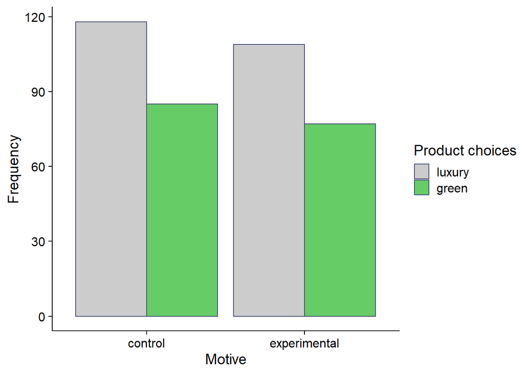

# Discussion

This study attempted to replicate the research question done by Griskevicius, Tybur, & Van den Bergh (2010): is buying green products driven by status motives? Their result showed the answer was “yes”, and this could be explained by a phrase “conspicuous consumption”: a behaviour that a person purchases an item to impress his or her wealth or status (Sundie, Kenrick, Griskevicius, Tybur, Vohs & Beal, 2011). In this case, by activating participants’ status motives, they chose green products to show their prosocial behaviours, and thus further impressed their social status.

However, compared to their study, we got a totally different result. Our result showed that participants who read the high-status story did not prefer green products, since the values for all chi-square were quite small, and the *p*-value proved the null hypothesis. Hence, we could conclude that there was no direct relationship between buying green products and the motivated social status. It was clear that we do not have a consistent result with the original paper.

In order to further check the accuracy of our result, we also found some other papers attempted in the similar topic. Sundie et al.(2011) had done a research which focused on the males’ mating targets according to their social status. The result has found that men with higher income could date with women more successfully than those with low income. This was another form of conspicuous consumption. Again, the result provided a positive evidence for the prediction. Another study done by Eidi and Shahbazi (2017) stated that higher social status facilitated buying green products. Similarily, Mainieri and his colleagues (1997) proved that people purchased green product to show their proenvironmental behaviour, which was another form of impressing their high social status. All of the studies above showed a consistence with the result gained by Griskevicius et al. (2010) but showed an inverse pattern with ours. Thus, there might be something wrong with our study.

Before talking about the limitations of this study, we first want to state some strengths. We strictly replicated the original study, using the same materials and research methods. Besides, we recruited a large amount of participants and ensured that all of them were in all the conditions, so that the final result was reliable. However, since we did not include an actual purchase in the experiment, we could not generalise our result to the whole population: that is, it is hard to say if in the reality, people still make the same dicision as in the experiment. Another shortage is that we only included participants from 18 years old to 29 years old. This might be a reason that we got a completely different result from the original study, since people in these ages seldom consider buying the products we provided (car, dishwasher and cleaner). Hence, some improvements are needed to prove whether the result we got was correct or not (e.g., includes participants in their middle age or change the product choices). However, from the current result we gained, we believe that people’s status motives do not make them buy green products more likely.

Future research should also focus on participants’ gender. It has been proven that women are more prosocial than men (Mainieri et al., 1997). Thus, it might be a potential factor that influences the final result. In the following steps, researchers can recruit only male participants, or separate male and female into two groups, to see whether gender would be a possible factor in determining people’s choices toward green products.

# References

Eidi, F., & Shahbazi, A. S. (2017). Effective factors on consumers’ decision to buy green products. *International Journal of Economic Perspectives*, 11(1), 795-807. Retrieved from https://search.proquest.com/docview/1964555028?accountid=14182

Griskevicius, V., Tybur, J. M., & Van den Bergh, B. (2010). Going green to be seen: Status, reputation, and conspicuous conservation. *Journal of Personality and Social Psychology*, 98(3), 392–404.

Hayat, K., Nadeem, A., & Jan, S. (2018). THE IMPACT OF ENVIRONMENTAL CONSCIOUSNESS, GREEN PRICE SENSITIVITY AND GREEN PRODUCT, ON GREEN PURCHASE INTENTION (A CASE OF PESHAWAR MARKET). *City University Research Journal*, 8(1), 103-116. Retrieved from https://search.proquest.com/docview/2120672854?accountid=14182

Joël Berger. (2017). Are Luxury Brand Labels and “Green” Labels Costly Signals of Social Status? An Extended Replication. PLoS ONE, 12(2), E0170216.

Mainieri, T., Barnett, E. G., Valdero, T., Unipan, J. B., & Oskamp, S. (1997). Green buying: The influence of environmental concern on consumer behavior. *The Journal of Social Psychology*, 137(2), 189-204. doi:http://dx.doi.org/10.1080/00224549709595430

Sundie, J. M., Kenrick, D. T., Griskevicius, V., Tybur, J. M., Vohs, K. D., & Beal, D. J. (2011). Peacocks, porsches, and thorstein veblen: Conspicuous consumption as a sexual signaling system. *Journal of Personality and Social Psychology*, 100(4), 664-680. doi:http://dx.doi.org/10.1037/a0021669